# Relatório de CE: Problema de Otimização do Transporte

Julho de 2020

Aluno: José Henrique Kleinübing Larcher

Professor: Heitor Silvério Lopes

# 1 Natureza do problema

Trata-se de um problema de otimização, onde o objetivo é maximixar o lucro, atendendo às restrições impostas pelo problema.

# 2 Conjunto de variáveis do problema e codificação

As variáveis do problema são dadas conforme a matriz a seguir, onde as linhas indicam as origens de viagem e as colunas indicam o destino.

$$X=\begin{bmatrix} 0 & x_{ 1 } & x_{ 2 } & x_{ 3 } & x_{ 4 } & x_{ 5 } & 0 \\ x_{ 6 } & x_{ 7 } & 0 & x_{ 8 } & 0 & x_{ 9 } & x_{ 10 } \\ 0 & x_{ 11 } & 0 & 0 & x_{ 12 } & 0 & x_{ 13 } \\ x_{ 14 } & 0 & x_{ 15 } & 0 & x_{ 16 } & x_{ 17 } & 0 \\ 0 & x_{ 18 } & x_{ 19 } & 0 & 0 & 0 & x_{ 20 } \\ 0 & 0 & 0 & x_{ 21 } & x_{ 22 } & x_{ 23 } & x_{ 24 } \\ x_{ 25 } & 0 & 0 & x_{ 26 } & x_{ 27 } & 0 & 0 \end{bmatrix}$$

Os valores de $x_i$ são o número de caminhões para uma determinada rota.

A codificação utilizada foi de número inteiro para cada valor de $x_i$, ou seja o gene é um vetor $<x>$ com 27 posições.

# 3 Restrições do problema

- O atendimento da demanda deve ser de no mínimo 72%.
- Cada viagem deve levar exatamente 11 carros.
- A velocidade do caminhão carregado é de 55 km/h.
- A velocidade do caminhão sem carga é 75 km/h.
- O tempo de carga e o tempo de descarga são de duas horas.
- A frota disponível é de 68 caminhões.
- O tempo máximo de viagem para cada caminhão é de 24 horas nos 30 dias do mês.

## 3.1 Matrizes do problema

$D$: matriz de demanda (máxima);

$d$: matriz de distânica entre as cidades;

$C$: matriz de custo por viagem;

$R$: matriz de remuneração por viagem.

O tempo de viagem para cada localidad epode ser calculado então da seguinte forma:

$$t_{ \text{ viagem } }=t_{ \text{ carga } }+t_{ \text{ descarga } }+\text{ceil}\left( \frac { d }{ v_{ \text{ com carga } } } \right) + \text{ceil} \left( \frac { d }{ v_{ \text{ sem carga } } } \right)$$

Onde $\text{ceil}(x)$ representa o arredondamento para cima de $x$. Os valores individuais para cada trajeto são chamados de $T$ (uma matriz).

## 3.2 Funções de restrição

$$h_1 = \text{max} \left( 0, \frac{\text{cobertura}_\text{min} - \text{cobertura}}{\text{cobertura}_\text{min}} \right)$$

$$h_2=\text{max} \left( 0,\frac{\text{total}\_\text{caminhoes}-\text{frota}_\text{max}} {\text{frota}_\text{max}} \right)$$

$$h_3= \text{max}\{0, \text{any}(\text{sum}(\text{sum}((\text{caminhoes} \ne 0) ) < 2)) \}$$

# 4 Função objetivo e função de fitness

A função objetivo utilizada é a que representa o lucro ($L$) com o número de caminhões ($X$). O número de viagens $V$ será:

$$V(X) = X \odot \text{floor} \left( \frac {t_{\text{max viagem}}}{T} \right)$$

Onde `floor` é o arredondamento para baixo e $\odot$ é a multiplicação elemento a elemento.

O lucro $L$ é então a função objetivo:

$$L(X) = \text{sum}\{R \odot V(X)\} - \text{sum}\{C \odot V(X)\}$$

Onde `sum` é a soma de todos os elementos da matriz.

Assim a função de fitness será:

$$\text{fit}(X) = L(X) - \frac{1}{3}\sum_{i=1}^{3}h_i$$

# 5 Solução ótima

## 5.1 Parâmetros

[output not shown]

## 5.2 Resultado

$$X=\begin{bmatrix}
0 & 4 & 0 & 3 & 3 & 5 & 0 \\
5 & 4 & 0 & 2 & 0 & 2 & 1 \\
0 & 3 & 0 & 0 & 1 & 0 & 2 \\
7 & 0 & 4 & 0 & 5 & 3 & 0 \\
0 & 5 & 0 & 0 & 0 & 0 & 1 \\
0 & 0 & 0 & 1 & 1 & 2 & 1 \\
1 & 0 & 0 & 1 & 1 & 0 & 0
\end{bmatrix}$$

$$\text{fit}(X) = 11.027.453,00$$

## 5.3 Gráfico da evolução

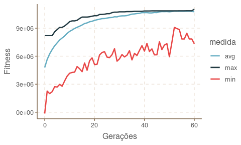

Notebook do programa: https://nbviewer.jupyter.org/github/jhklarcher/computacao_evolucionaria/blob/master/trabalhos/01_transporte/programa_JoseLarcher.ipynb